# Unweighted Regressions

Tianran Zhang

6/6/2020

```r
load("../Data/ESP_reg.RData")
load("../Data/PIAAC.RData")
# load("../Data/ESP.RData")
```

```r
ESP <- ESP.reg
```

# Investigae the association between numeracy and self-reported health status

## Regression analysis for ESP

**Step-wise multivariate linear regression**  
* Outcome: binary health status

1. Original Levels (Multi-level/Excellent/Very good/Good/Fair/Poor/Unknown)
2. Health status 1(Binary): Not Poor VS. Poor
3. Health status 2 (Binary): Good VS. Not Good
- Predictor: numeracy score
- Covariates: education, ethincity, income, race
- Interaction term: education & numeracy score

### Health status 1(Binary): Not Poor VS. Poor

```r
ESP$health_status_1 <- relevel(ESP$health_status_1, ref = "Not Poor")
full1 <- glm(health_status_1 ~ numeracy + educ + hisp + race +
               income.cat + educ:numeracy, data = ESP,
             family = "binomial")
final1 <- step(full1, direction = "both", trace = 0)
multi_summary1 <- exp(cbind(coef(final1), confint(final1))[-1, ]) %>% as.data.frame()
colnames(multi_summary1)[1] <- "OR"
multi_summary1$sig <- ifelse(summary(final1)$coefficients[-1, 4] < 0.05, "*", "")

# power calculation
powerSim(final1, nsim = 100,  progress = FALSE)
```

```
## Power for predictor 'educ', (95% confidence interval):
##       88.00% (79.98, 93.64)
##
## Test: Likelihood ratio
##
## Based on 100 simulations, (4 warnings, 0 errors)
## alpha = 0.05, nrow = 766
##
## Time elapsed: 0 h 0 m 1 s
##
## nb: result might be an observed power calculation
```

```r
kable(multi_summary1) %>%
  kable_styling()
```

OR

2.5 %

97.5 %

sig

educSome college or associate’s degree

6.051711e-01

0.2499284

1.417051e+00

educBachelor’s degree or higher

1.553116e-01

0.0343948

5.082280e-01

hispNon-hispanic

1.836026e+00

0.6698609

6.478741e+00

hispRefused

6.833716e+09

0.0000000

NA

income.cat$50k-$100k

5.433770e-01

0.2140466

1.273162e+00

income.cat$100k-$150k

1.916413e-01

0.0104461

9.862235e-01

income.cat$150k+

1.000000e-07

NA

2.535501e+13

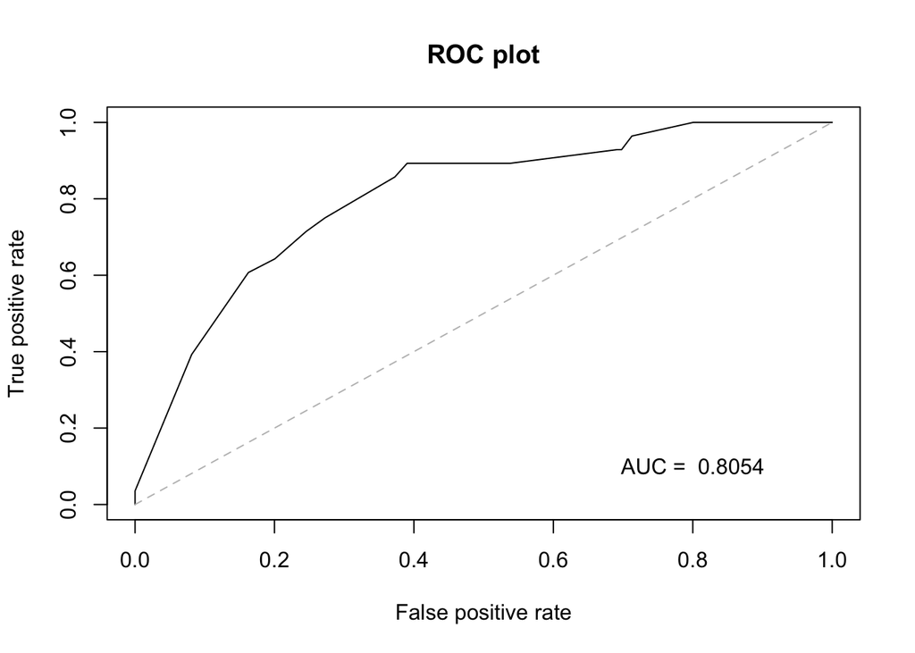

```r
# ROC curve
rocplot <- function(truth, pred, ...){
  predob = prediction(pred, truth)
  perf = performance(predob, "tpr", "fpr")
  plot(perf, colorize=F, ...)
  area = auc(truth, pred)
  area = format(round(area, 4), nsmall = 4)
  text(x = .8, y = .1, labels = paste("AUC = ", area))
  segments(x0 = 0, y0 = 0, x1 = 1, y1 = 1, col = "gray", lty = 2)
}

rocplot(ESP$health_status_1, predict.glm(final1, ESP, type = "response"), title = "ROC plot")
title(main = "ROC plot")
```

### Health status 2 (Binary): Good VS. Not Good

```r
ESP$health_status_2 <- relevel(ESP$health_status_2, ref = "Good")
full2 <- glm(health_status_2 ~ numeracy + educ + hisp + race +
               income.cat + educ*numeracy, data = ESP,
             family = "binomial")

final2 <- step(full2, direction = "both", trace = 0)
multi_summary2 <- exp(cbind(coef(final2), confint(final2))[-1, ]) %>% as.data.frame()
colnames(multi_summary2)[1] <- "OR"
multi_summary2$sig <- ifelse(summary(final2)$coefficients[-1, 4] < 0.05, "*", "")


# power calculation
powerSim(final2, nsim = 100, progress = FALSE)
```

```
## Power for predictor 'numeracy', (95% confidence interval):
##       100.0% (96.38, 100.0)
##
## Test: z-test
##
## Based on 100 simulations, (0 warnings, 0 errors)
## alpha = 0.05, nrow = 766
##
## Time elapsed: 0 h 0 m 1 s
##
## nb: result might be an observed power calculation
```

```r
kable(multi_summary2) %>%
  kable_styling()
```

OR

2.5 %

97.5 %

sig

numeracy

1.6879627

1.4384586

2.0563690

educSome college or associate’s degree

0.4444128

0.0217289

8.4847550

educBachelor’s degree or higher

0.0079406

0.0001168

0.3365974

hispNon-hispanic

0.3665369

0.1519765

0.8151726

hispRefused

7335.7461856

0.0000000

NA

numeracy:educSome college or associate’s degree

1.0940143

0.8426113

1.4271384

numeracy:educBachelor’s degree or higher

1.4985920

1.0892092

2.1497434

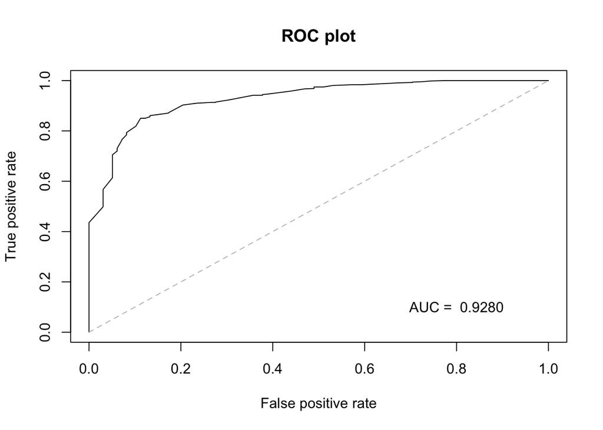

```r
# ROC curve
rocplot(ESP$health_status_2, predict.glm(final2, ESP, type = "response"), title = "ROC plot")
title(main = "ROC plot")
```

## Regression Analysis for PIAAC data

Step-wise multivariate linear regression

- Outcome: binary health status
- predictor: numeracy score
- covariates: income, race, education
- Interaction term: education & numeracy score

### Health status 1(Binary): Not Poor VS. Poor

```r
PIAAC_clean <- PIAAC %>%
  filter(health_status != "Unknown") %>%
  mutate(health_status_1 = factor(health_status_1),
         health_status_2 = factor(health_status_2))
PIAAC_clean$race[PIAAC_clean$race == "Unknown"] = "Other"
PIAAC_clean$race <- factor(PIAAC_clean$race)
```

```r
full1 <- glm(health_status_1 ~ numeracy + educ + income.cat + race + educ * numeracy, data = PIAAC_clean, family = "binomial")
final1 <- step(full1, direction = "both", trace = 0)
multi_summary1 <- exp(cbind(coef(final1), confint(final1))[-1, ]) %>% as.data.frame()
colnames(multi_summary1)[1] <- "OR"
multi_summary1$sig <- ifelse(summary(final1)$coefficients[-1, 4] < 0.05, "*", "")

# power calculation
powerSim(final1, nsim = 100, progress = FALSE)
```

```
## Power for predictor 'numeracy', (95% confidence interval):
##       99.00% (94.55, 99.97)
##
## Test: z-test
##
## Based on 100 simulations, (0 warnings, 0 errors)
## alpha = 0.05, nrow = 3475
##
## Time elapsed: 0 h 0 m 2 s
##
## nb: result might be an observed power calculation
```

```r
kable(multi_summary1) %>%
  kable_styling()
```

OR

2.5 %

97.5 %

sig

numeracy

0.9914632

0.9879394

0.9949974

income.cat$50k-$100k

0.2473048

0.1323368

0.4301698

income.cat$100k-$150k

0.1800494

0.0540831

0.4447955

income.cat$150k+

0.3049461

0.1044619

0.7094185

income.catNo Data

0.4999209

0.2487327

0.9112216

raceBlack

0.3592459

0.1882360

0.6403883

raceAsian/pacific islander

0.3365591

0.0545248

1.1045800

raceHispanic

0.4646276

0.2456302

0.8249682

raceOther

0.8910029

0.3609439

1.8838859

Step-wise multivariate regression model was conducted on PIAAC data. The final model has three predictors (numeracy, income and race). The AUC is 0.7469 with ROC curve shown below.

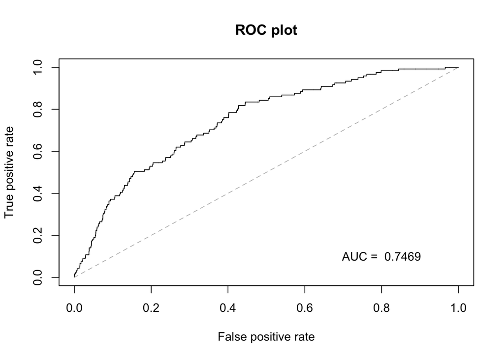

```r
# ROC curve

rocplot(PIAAC_clean$health_status_1, predict.glm(final1, PIAAC_clean, type = "response", na.action = na.omit), title = "ROC plot")
title(main = "ROC plot")
```

### Health status 2(Binary): Good VS. Not Good

```r
full2 <- glm(health_status_2 ~ numeracy + educ + income.cat + race +
               numeracy * educ, data = PIAAC_clean, family = "binomial")
final2 <- step(full2, direction = "both", trace = 0)
multi_summary2 <- exp(cbind(coef(final2), confint(final2))[-1, ]) %>%
  as.data.frame()
colnames(multi_summary2)[1] <- "OR"
multi_summary2$sig <- ifelse(summary(final2)$coefficients[-1, 4] < 0.05, "*", "")

# power calculation
powerSim(final2, nsim = 100, progress = FALSE)
```

```
## Power for predictor 'numeracy', (95% confidence interval):
##       100.0% (96.38, 100.0)
##
## Test: z-test
##
## Based on 100 simulations, (0 warnings, 0 errors)
## alpha = 0.05, nrow = 3475
##
## Time elapsed: 0 h 0 m 2 s
##
## nb: result might be an observed power calculation
```

```r
kable(multi_summary2) %>%
  kable_styling()
```

OR

2.5 %

97.5 %

sig

numeracy

0.9933186

0.9914155

0.9952095

educSome college or associate’s degree

0.7987630

0.6215252

1.0203175

educBachelor’s degree or higher

0.6230974

0.4783168

0.8075300

educUnknown

1.0583745

0.0479910

11.5736707

income.cat$50k-$100k

0.5013844

0.3970557

0.6303923

income.cat$100k-$150k

0.3004075

0.1978091

0.4421897

income.cat$150k+

0.3630046

0.2308367

0.5511575

income.catNo Data

0.4684542

0.3349323

0.6441355

raceBlack

0.6380557

0.4842917

0.8344411

raceAsian/pacific islander

0.5175274

0.2769678

0.8976832

raceHispanic

0.7311092

0.5499500

0.9638656

raceOther

1.2241207

0.7968727

1.8441080

Step-wise multivariate regression model was conducted. The final model has four predictors (numeracy, education, income and race). The AUC is 0.7098 with ROC curve shown below.

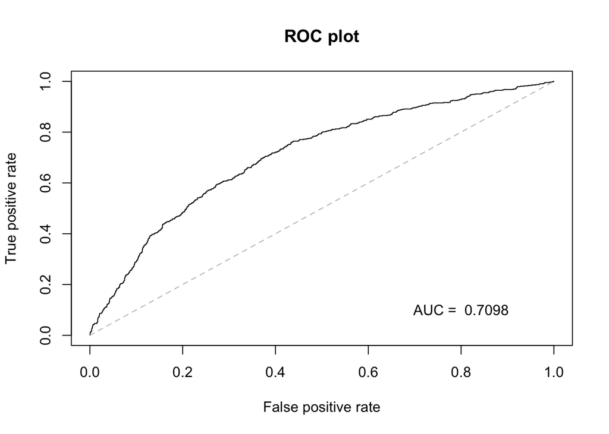

```r
rocplot(PIAAC_clean$health_status_2, predict.glm(final2, PIAAC_clean, type = "response", na.action = na.omit), title = "ROC plot")
title(main = "ROC plot")
```

## Considering the additional predictors in PIAAC: Literacy, Problem solving abilities.

### Health status 1(Binary): Not Poor VS. Poor

- Outcome: health_status_1  
  Poor: health score >=5;  
  Not Poor: health score < 5.
- Predictor: numeracy score
- Covariates: education, income, race, literacy and problem solving.

```r
PIAAC_clean2 <- na.omit(PIAAC_clean)
```

```r
full3 <- glm(health_status_1 ~ numeracy + educ + income.cat + race +
               literacy + problem_solving,
             data = PIAAC_clean[complete.cases(PIAAC_clean), ],
             family = "binomial")
final3 <- step(full3, direction = "both", trace = 0)
multi_summary3 <- exp(cbind(coef(final3), confint(final3))[-1, ]) %>%
  as.data.frame()
colnames(multi_summary3)[1] <- "OR"
multi_summary3$sig <- ifelse(summary(final3)$coefficients[-1, 4] < 0.05, "*", "")

# power calculation
powerSim(final3, nsim = 100, progress = FALSE)
```

```
## Power for predictor 'numeracy', (95% confidence interval):
##       100.0% (96.38, 100.0)
##
## Test: z-test
##
## Based on 100 simulations, (15 warnings, 0 errors)
## alpha = 0.05, nrow = 2869
##
## Time elapsed: 0 h 0 m 3 s
##
## nb: result might be an observed power calculation
```

```r
kable(multi_summary3) %>%
  kable_styling()
```

OR

2.5 %

97.5 %

sig

numeracy

1.0216318

1.0123353

1.0312027

educSome college or associate’s degree

0.3537231

0.1422579

0.7586971

educBachelor’s degree or higher

0.6207869

0.3058249

1.2083179

educUnknown

0.0000012

NA

Inf

income.cat$50k-$100k

0.2437980

0.1127080

0.4806268

income.cat$100k-$150k

0.1129851

0.0180018

0.3855025

income.cat$150k+

0.2638581

0.0744575

0.7228169

income.catNo Data

0.4842423

0.1802922

1.0901694

raceBlack

0.3753084

0.1252747

0.9091925

raceAsian/pacific islander

0.0000004

0.0000000

398.0009688

raceHispanic

0.7729337

0.3052373

1.7013410

raceOther

1.2319930

0.3598581

3.1992854

problem_solving

0.9668754

0.9571238

0.9764067

Step-wise multivariate regression model was conducted. The final model has five predictors (numeracy, educ, income, race and problem solving). The AUC is 0.8198 with ROC curve shown below.

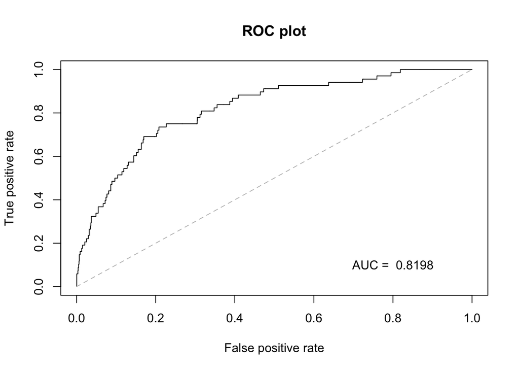

```r
rocplot(PIAAC_clean2$health_status_1, predict.glm(final3, PIAAC_clean2, type = "response", na.action = na.omit), title = "ROC plot")
title(main = "ROC plot")
```

### Health status 2(Binary): Good VS. Not Good

```r
full4 <- glm(health_status_2 ~ numeracy + educ + income.cat + race +
               literacy + problem_solving,
             data = PIAAC_clean[complete.cases(PIAAC_clean), ],
             family = "binomial")
final4 <- step(full4, direction = "both", trace = 0)
multi_summary4 <- exp(cbind(coef(final4), confint(final4))[-1, ]) %>%
  as.data.frame()
colnames(multi_summary4)[1] <- "OR"
multi_summary4$sig <- ifelse(summary(final4)$coefficients[-1, 4] < 0.05, "*", "")

# power calculation
powerSim(final4, nsim = 100, progress = FALSE)
```

```
## Power for predictor 'numeracy', (95% confidence interval):
##       42.00% (32.20, 52.29)
##
## Test: z-test
##
## Based on 100 simulations, (0 warnings, 0 errors)
## alpha = 0.05, nrow = 2869
##
## Time elapsed: 0 h 0 m 2 s
##
## nb: result might be an observed power calculation
```

```r
kable(multi_summary4) %>%
  kable_styling()
```

OR

2.5 %

97.5 %

sig

numeracy

1.0034716

0.9995494

1.007421e+00

educSome college or associate’s degree

0.8222796

0.6159035

1.089394e+00

educBachelor’s degree or higher

0.6296484

0.4672523

8.440740e-01

educUnknown

0.0000248

NA

1.342412e+24

income.cat$50k-$100k

0.5245219

0.4009904

6.828033e-01

income.cat$100k-$150k

0.3148559

0.1997320

4.793775e-01

income.cat$150k+

0.3657722

0.2219526

5.791798e-01

income.catNo Data

0.4356182

0.2814179

6.527841e-01

raceBlack

0.7614976

0.5383133

1.062657e+00

raceAsian/pacific islander

0.5656442

0.2606496

1.085350e+00

raceHispanic

0.9461083

0.6600647

1.335527e+00

raceOther

1.4661384

0.8896909

2.342415e+00

problem_solving

0.9895134

0.9854061

9.936098e-01

Step-wise multivariate regression model was conducted. The final model has five predictors (numeracy, educ, income, race and problem_solving). The AUC is 0.6907 with ROC curve shown below.

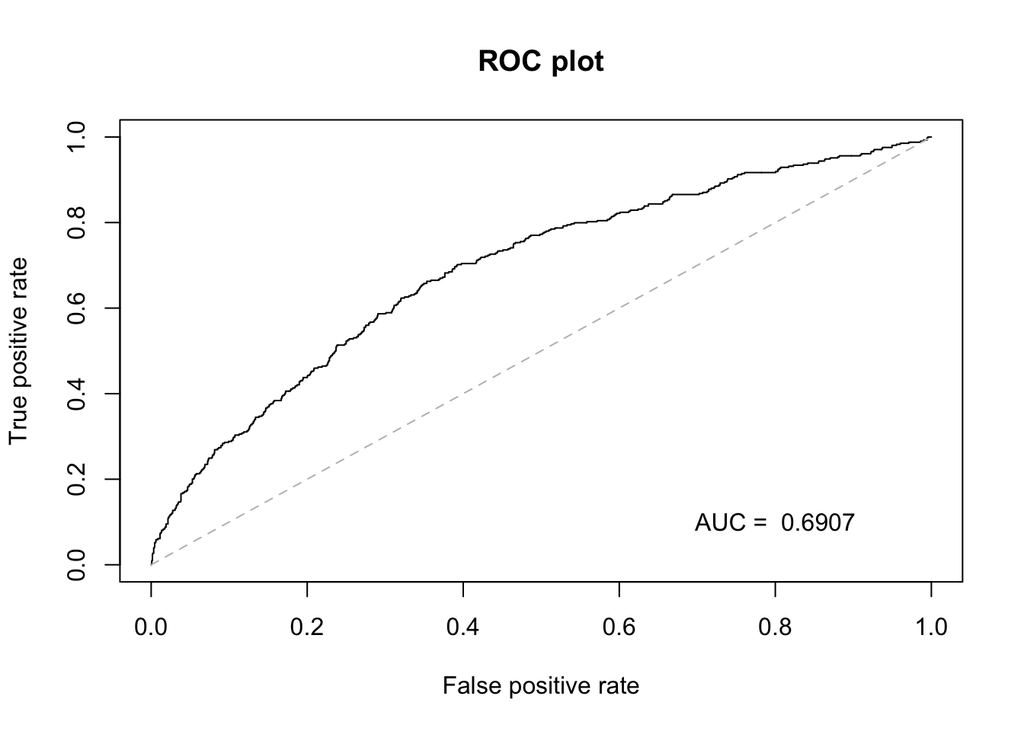

```r
rocplot(PIAAC_clean2$health_status_2, predict.glm(final4, PIAAC_clean2, type = "response", na.action = na.omit), title = "ROC plot")
title(main = "ROC plot")
```

### Summary

**Empire State Poll (ESP)**

Step-wise multivariate linear regression

- Outcome: binary health status
1. Original Levels (Multi-level/Excellent/Very good/Good/Fair/Poor/Unknown)
2. Health status 1(Binary): Not Poor VS. Poor
3. Health status 2 (Binary): Good VS. Not Good
- Predictor: numeracy score
- Covariates: education, ethincity, income, race
- Interaction term: education & numeracy score

[output not shown]

**Program for the International Assessment of Adult Competencies (PIAAC 2017)**

Step-wise multivariate linear regression

- Outcome: binary health status
- predictor: numeracy score
- covariates: income, race, education
- Interaction term: education & numeracy score

[output not shown]

Considering additional covariates:

- Outcome: binary health status
- predictor: numeracy score, literacy performance, problem solving
- covariates: income, race, education

[output not shown]

# Binary visits to doctors outcome

## Regression analysis for ESP data

**Step-wise multivariate linear regression**

- Outcome: binary visits to doctors
1. Original Levels (Never/1-2 times/Once every few months/Once a month/Twice a month/Once a week/2-3 times a week)

```r
quantile(ESP$RVq2)
```

```
##   0%  25%  50%  75% 100%
##    1    2    3    3    7
```

```r
table(ESP$RVq2)
```

```
##
##   1   2   3   4   5   6   7
##  69 223 288  97  56  23  10
```

2. Visit status (Binary): Not often (#visits <=2) VS. Often (#visits >= 3)
- Predictor: numeracy score
- Covariates: education, ethincity, income, race
- Interaction term: education & numeracy score

```r
ESP$visit_often <- factor(ifelse(ESP$RVq2 >=3, 1, 0))

full1 <- glm(visit_often ~ numeracy + educ + hisp + race + income.cat +
               educ:numeracy, data = ESP,
             family = "binomial")
final1 <- step(full1, direction = "both", trace = 0)
multi_summary1 <- exp(cbind(coef(final1), confint(final1))[-1, ]) %>% as.data.frame()
colnames(multi_summary1)[1] <- "OR"
multi_summary1$sig <- ifelse(summary(final1)$coefficients[-1, 4] < 0.05, "*", "")

# power calculation
powerSim(final1, nsim = 100, progress = FALSE)
```

```
## Power for predictor 'numeracy', (95% confidence interval):
##       31.00% (22.13, 41.03)
##
## Test: z-test
##
## Based on 100 simulations, (0 warnings, 0 errors)
## alpha = 0.05, nrow = 766
##
## Time elapsed: 0 h 0 m 0 s
##
## nb: result might be an observed power calculation
```

```r
kable(multi_summary1) %>%
  kable_styling()
```

OR

2.5 %

97.5 %

sig

numeracy

9.634919e-01

0.9170918

1.011178

educSome college or associate’s degree

1.336402e+00

0.8842671

2.022149

educBachelor’s degree or higher

1.885487e+00

1.2700415

2.802872

hispNon-hispanic

1.517863e+00

0.9775068

2.354694

hispRefused

1.172281e+06

0.0000000

NA

raceBlack

6.470453e-01

0.4152637

1.012314

raceOther

6.059540e-01

0.4020707

0.914810

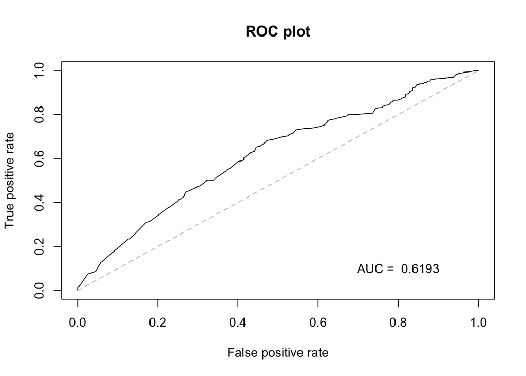

```r
rocplot(ESP$visit_often, predict.glm(final1, ESP, type = "response"), title = "ROC plot")
title(main = "ROC plot")
```

### Summary

[output not shown]